# bdlnm

```r
library(bdlnm)
library(dlnm)
library(splines)
library(utils)
```

# london dataset

As an example for this vignette, we will use the built-in dataset `london` which contains daily temperature and mortality data from 2000 to 2012.

```r
head(london)
```

```
#>         date year dow    tmean mort_00_74 mort_75plus mort
#> 1 2000-01-01 2000 Sat 7.642016        101         226  327
#> 2 2000-01-02 2000 Sun 8.351041        100         191  291
#> 3 2000-01-03 2000 Mon 8.188446        107         205  312
#> 4 2000-01-04 2000 Tue 6.320066         97         191  288
#> 5 2000-01-05 2000 Wed 6.550981         92         213  305
#> 6 2000-01-06 2000 Thu 8.728774         82         213  295
```

Using Bayesian Distributed Non-Linear Models (B-DLNM) we will estimate the lagged effect of the temperature exposure to mortality in the population with more than 75 years old, taking 21 days of lags, in the city of London (2000-2012).

# Set DLNM parameters

We will start by building the crossbasis with the `dlnm` package.

We will use a natural spline with three knots for the exposure–response function, placed at the 10th, 75th, and 90th percentiles of daily mean temperature, and a natural spline for the lag–response function, with knots equally spaced on the log scale up to a maximum lag of 21 days:

```r
# Exposure-response and lag-response spline parameters
dlnm_var <- list(
  var_prc = c(10, 75, 90),
  var_fun = "ns",
  lag_fun = "ns",
  max_lag = 21,
  lagnk = 3
)


# Cross-basis parameters
argvar <- list(
  fun = dlnm_var$var_fun,
  knots = quantile(london$tmean, dlnm_var$var_prc / 100, na.rm = TRUE),
  Bound = range(london$tmean, na.rm = TRUE)
)

arglag <- list(
  fun = dlnm_var$lag_fun,
  knots = logknots(dlnm_var$max_lag, nk = dlnm_var$lagnk)
)

# Create crossbasis
cb <- crossbasis(london$tmean, lag = dlnm_var$max_lag, argvar, arglag)
```

Let’s define the seasonality of the mortality time series using a natural spline with 8 degrees of freedom per year, which flexibly controls for long-term and seasonal trends in mortality:

```r
# Seasonality of mortality time series
seas <- ns(london$date, df = round(8 * length(london$date) / 365.25))
```

Finally, we also define the temperature values for which predictions will be generated. These correspond to an evenly spaced grid with a 0.1ºC step covering the full range of observed temperatures in the data:

```r
# Prediction values (equidistant points)
temp <- round(seq(min(london$tmean), max(london$tmean), by = 0.1), 1)
# Ensure it falls inside the range of temperatures after rounding:
temp <- temp[temp >= min(london$tmean) & temp <= max(london$tmean)]
```

# Fit the model and posterior samples

Fit the Bayesian DLNM using the function `bdlnm()`. In this example, we specify a Poisson model including the cross-basis term, a seasonal component, and an indicator for the day of the week. We draw 1000 samples from the posterior distribution and set a seed for reproducibility.

```r
mod <- bdlnm(
  mort_75plus ~ cb + factor(dow) + seas,
  data = london,
  family = "poisson",
  sample.arg = list(n = 1000, seed = 5243)
)
```

The returned object is of class bdlnm and contains the fitted INLA model, the crossbasis objects included in the formula, and posterior samples of the estimated coefficients together with their summaries (mean, standard deviation, and quantiles).

```r
str(mod, max.level = 1)
```

```
#> List of 4
#>  $ model               :List of 49
#>   ..- attr(*, "class")= chr "inla"
#>  $ basis               :List of 1
#>  $ coefficients        : num [1:123, 1:1000] 5.17713 -0.13925 -0.00779 -0.05735 0.0489 ...
#>   ..- attr(*, "dimnames")=List of 2
#>  $ coefficients.summary: num [1:123, 1:6] 5.20497 -0.13495 -0.00608 -0.04971 0.04957 ...
#>   ..- attr(*, "dimnames")=List of 2
#>  - attr(*, "n_sim")= num 1000
#>  - attr(*, "class")= chr "bdlnm"
```

# Minimum mortality temperature

We estimate the minimum mortality temperature (MMT), defined as the temperature at which the overall mortality risk is minimized. This optimal value will later be used to center the estimated relative risks.

```r
mmt <- optimal_exposure(mod, exp_at = temp)
str(mmt)
```

```
#> List of 2
#>  $ est    : Named num [1:1000] 19 19 18.8 18.7 19.1 19.1 18.7 18.9 18.8 19.1 ...
#>   ..- attr(*, "names")= chr [1:1000] "sample1" "sample2" "sample3" "sample4" ...
#>  $ summary: Named num [1:6] 18.9 0.144 18.6 18.9 19.2 ...
#>   ..- attr(*, "names")= chr [1:6] "mean" "sd" "0.025quant" "0.5quant" ...
#>  - attr(*, "exp_at")= num [1:326] -3.4 -3.3 -3.2 -3.1 -3 -2.9 -2.8 -2.7 -2.6 -2.5 ...
#>  - attr(*, "lag_at")= num [1:22] 0 1 2 3 4 5 6 7 8 9 ...
#>  - attr(*, "which")= chr "min"
#>  - attr(*, "class")= chr "optimal_exposure"
```

We can visualize the posterior distribution of the MMT estimates. It is useful to inspect this distribution to assess whether multiple candidate optimal exposure values exist and to verify that the median provides a reasonable centering value:

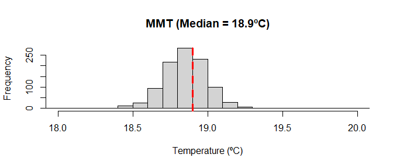

```r
plot(
  mmt,
  xlab = "Temperature (ºC)",
  main = paste0("MMT (Median = ", round(mmt$summary[["0.5quant"]], 1), "ºC)")
)
```

To make the predictions, we will center the risk at the median of these values:

```r
cen <- mmt$summary[["0.5quant"]]
cen
```

```
#> [1] 18.9
```

# Predict exposure-lag-response effects

Predict the exposure–lag–response association between temperature and mortality from the fitted model at the supplied temperature grid, centering the predictions at the MMT value:

```r
cpred <- bcrosspred(mod, exp_at = temp, cen = cen)
```

A `bcrosspred` object is returned containing posterior samples of the estimated exposure–lag–response association for the supplied temperature values and lags, together with their summaries.

```r
str(cpred)
```

```
#> List of 16
#>  $ exp_at              : num [1:326] -3.4 -3.3 -3.2 -3.1 -3 -2.9 -2.8 -2.7 -2.6 -2.5 ...
#>  $ lag_at              : num [1:22] 0 1 2 3 4 5 6 7 8 9 ...
#>  $ cen                 : num 18.9
#>  $ coefficients        : num [1:20, 1:1000] -0.13925 -0.00779 -0.05735 0.0489 -0.04849 ...
#>   ..- attr(*, "dimnames")=List of 2
#>   .. ..$ : chr [1:20] "cbv1.l1" "cbv1.l2" "cbv1.l3" "cbv1.l4" ...
#>   .. ..$ : chr [1:1000] "sample1" "sample2" "sample3" "sample4" ...
#>  $ matfit              : num [1:326, 1:22, 1:1000] -0.164 -0.163 -0.162 -0.161 -0.161 ...
#>   ..- attr(*, "dimnames")=List of 3
#>   .. ..$ : chr [1:326] "-3.4" "-3.3" "-3.2" "-3.1" ...
#>   .. ..$ : chr [1:22] "lag0" "lag1" "lag2" "lag3" ...
#>   .. ..$ : chr [1:1000] "sample1" "sample2" "sample3" "sample4" ...
#>  $ allfit              : num [1:326, 1:1000] 0.712 0.706 0.7 0.694 0.689 ...
#>   ..- attr(*, "dimnames")=List of 2
#>   .. ..$ : chr [1:326] "-3.4" "-3.3" "-3.2" "-3.1" ...
#>   .. ..$ : chr [1:1000] "sample1" "sample2" "sample3" "sample4" ...
#>  $ matRRfit            : num [1:326, 1:22, 1:1000] 0.849 0.85 0.85 0.851 0.852 ...
#>   ..- attr(*, "dimnames")=List of 3
#>   .. ..$ : chr [1:326] "-3.4" "-3.3" "-3.2" "-3.1" ...
#>   .. ..$ : chr [1:22] "lag0" "lag1" "lag2" "lag3" ...
#>   .. ..$ : chr [1:1000] "sample1" "sample2" "sample3" "sample4" ...
#>  $ allRRfit            : num [1:326, 1:1000] 2.04 2.03 2.01 2 1.99 ...
#>   ..- attr(*, "dimnames")=List of 2
#>   .. ..$ : chr [1:326] "-3.4" "-3.3" "-3.2" "-3.1" ...
#>   .. ..$ : chr [1:1000] "sample1" "sample2" "sample3" "sample4" ...
#>  $ coefficients.summary: num [1:20, 1:6] -0.13495 -0.00608 -0.04971 0.04957 -0.04897 ...
#>   ..- attr(*, "dimnames")=List of 2
#>   .. ..$ : chr [1:20] "cbv1.l1" "cbv1.l2" "cbv1.l3" "cbv1.l4" ...
#>   .. ..$ : chr [1:6] "mean" "sd" "0.025quant" "0.5quant" ...
#>  $ matfit.summary      : num [1:326, 1:22, 1:6] -0.159 -0.159 -0.158 -0.157 -0.156 ...
#>   ..- attr(*, "dimnames")=List of 3
#>   .. ..$ : chr [1:326] "-3.4" "-3.3" "-3.2" "-3.1" ...
#>   .. ..$ : chr [1:22] "lag0" "lag1" "lag2" "lag3" ...
#>   .. ..$ : chr [1:6] "mean" "sd" "0.025quant" "0.5quant" ...
#>  $ allfit.summary      : num [1:326, 1:6] 0.611 0.606 0.602 0.598 0.594 ...
#>   ..- attr(*, "dimnames")=List of 2
#>   .. ..$ : chr [1:326] "-3.4" "-3.3" "-3.2" "-3.1" ...
#>   .. ..$ : chr [1:6] "mean" "sd" "0.025quant" "0.5quant" ...
#>  $ matRRfit.summary    : num [1:326, 1:22, 1:6] 0.853 0.853 0.854 0.855 0.855 ...
#>   ..- attr(*, "dimnames")=List of 3
#>   .. ..$ : chr [1:326] "-3.4" "-3.3" "-3.2" "-3.1" ...
#>   .. ..$ : chr [1:22] "lag0" "lag1" "lag2" "lag3" ...
#>   .. ..$ : chr [1:6] "mean" "sd" "0.025quant" "0.5quant" ...
#>  $ allRRfit.summary    : num [1:326, 1:6] 1.84 1.83 1.83 1.82 1.81 ...
#>   ..- attr(*, "dimnames")=List of 2
#>   .. ..$ : chr [1:326] "-3.4" "-3.3" "-3.2" "-3.1" ...
#>   .. ..$ : chr [1:6] "mean" "sd" "0.025quant" "0.5quant" ...
#>  $ ci.level            : num 0.95
#>  $ model.class         : chr "inla"
#>  $ model.link          : chr "log"
#>  - attr(*, "class")= chr "bcrosspred"
```

For instance, the estimated `crossbasis` coefficients are stored as:

```r
cpred$coefficients |>
  head(c(5, 5))
```

```
#>              sample1      sample2      sample3      sample4      sample5
#> cbv1.l1 -0.139254820 -0.154092463 -0.112435103 -0.110085718 -0.153345807
#> cbv1.l2 -0.007785162  0.008057831  0.001246025 -0.003957057  0.006234502
#> cbv1.l3 -0.057349056 -0.056023923 -0.045405679 -0.044017954 -0.055955602
#> cbv1.l4  0.048904544  0.057243423  0.025429828  0.028536089  0.049960368
#> cbv1.l5 -0.048493123 -0.046565133 -0.034679488 -0.034910980 -0.049022859
```

The relative risks (RR) for each temperature–lag combination are also stored in an array for each posterior sample. For example, for the first sample:

```r
cpred$matRRfit[,, "sample1"] |>
  head()
```

```
#>           lag0     lag1     lag2     lag3     lag4     lag5     lag6     lag7
#> -3.4 0.8489699 1.078465 1.144323 1.100592 1.064684 1.044508 1.035173 1.032374
#> -3.3 0.8496304 1.077665 1.143102 1.099767 1.064167 1.044168 1.034920 1.032156
#> -3.2 0.8502913 1.076867 1.141883 1.098942 1.063651 1.043827 1.034668 1.031938
#> -3.1 0.8509526 1.076069 1.140665 1.098119 1.063136 1.043488 1.034416 1.031720
#> -3   0.8516143 1.075272 1.139449 1.097296 1.062620 1.043148 1.034163 1.031502
#> -2.9 0.8522763 1.074476 1.138235 1.096475 1.062106 1.042809 1.033912 1.031285
#>          lag8     lag9    lag10    lag11    lag12    lag13    lag14    lag15
#> -3.4 1.032072 1.031846 1.031526 1.031122 1.030641 1.030090 1.029478 1.028812
#> -3.3 1.031866 1.031648 1.031335 1.030934 1.030453 1.029902 1.029287 1.028618
#> -3.2 1.031661 1.031451 1.031143 1.030745 1.030266 1.029714 1.029097 1.028424
#> -3.1 1.031455 1.031253 1.030951 1.030557 1.030079 1.029526 1.028907 1.028230
#> -3   1.031250 1.031056 1.030759 1.030368 1.029892 1.029339 1.028717 1.028036
#> -2.9 1.031045 1.030859 1.030568 1.030180 1.029705 1.029151 1.028527 1.027843
#>         lag16    lag17    lag18    lag19    lag20    lag21
#> -3.4 1.028100 1.027350 1.026570 1.025767 1.024950 1.024126
#> -3.3 1.027901 1.027145 1.026358 1.025548 1.024723 1.023890
#> -3.2 1.027702 1.026940 1.026146 1.025329 1.024495 1.023655
#> -3.1 1.027503 1.026735 1.025934 1.025109 1.024268 1.023420
#> -3   1.027304 1.026530 1.025723 1.024890 1.024041 1.023184
#> -2.9 1.027106 1.026326 1.025511 1.024671 1.023814 1.022950
```

The overall cumulative effects for each temperature (summing across all lags) are stored in:

```r
cpred$allRRfit |>
  head(c(5, 5))
```

```
#>       sample1  sample2  sample3  sample4  sample5
#> -3.4 2.037760 1.878217 1.737032 1.745590 1.813982
#> -3.3 2.025954 1.870825 1.731703 1.738016 1.805661
#> -3.2 2.014218 1.863462 1.726390 1.730476 1.797380
#> -3.1 2.002555 1.856132 1.721094 1.722970 1.789138
#> -3   1.990964 1.848833 1.715816 1.715501 1.780939
```

Summaries of these effects across posterior samples are also available:

```r
cpred$matRRfit.summary |>
  head(5)
```

```
#> , , mean
#>
#>           lag0     lag1     lag2     lag3     lag4     lag5     lag6     lag7
#> -3.4 0.8526728 1.071554 1.134939 1.094427 1.060321 1.040427 1.030439 1.026554
#> -3.3 0.8533699 1.070944 1.133932 1.093743 1.059897 1.040154 1.030245 1.026395
#> -3.2 0.8540676 1.070335 1.132926 1.093060 1.059473 1.039882 1.030051 1.026236
#> -3.1 0.8547656 1.069726 1.131921 1.092377 1.059049 1.039609 1.029858 1.026078
#> -3   0.8554641 1.069118 1.130917 1.091695 1.058626 1.039337 1.029665 1.025919
#>          lag8     lag9    lag10    lag11    lag12    lag13    lag14    lag15
#> -3.4 1.025215 1.024283 1.023584 1.023100 1.022810 1.022694 1.022734 1.022909
#> -3.3 1.025071 1.024149 1.023458 1.022977 1.022688 1.022571 1.022607 1.022777
#> -3.2 1.024928 1.024016 1.023332 1.022855 1.022567 1.022448 1.022480 1.022645
#> -3.1 1.024784 1.023883 1.023205 1.022732 1.022445 1.022325 1.022354 1.022512
#> -3   1.024640 1.023750 1.023079 1.022610 1.022324 1.022202 1.022227 1.022380
#>         lag16    lag17    lag18    lag19    lag20    lag21
#> -3.4 1.023201 1.023591 1.024058 1.024583 1.025148 1.025733
#> -3.3 1.023062 1.023442 1.023899 1.024414 1.024967 1.025540
#> -3.2 1.022922 1.023293 1.023740 1.024244 1.024786 1.025347
#> -3.1 1.022782 1.023145 1.023582 1.024075 1.024606 1.025155
#> -3   1.022642 1.022996 1.023423 1.023906 1.024425 1.024963
#>
#> , , sd
#>
#>          lag0     lag1     lag2     lag3     lag4     lag5     lag6     lag7
#> -3.4 1.023629 1.011022 1.013014 1.006847 1.006050 1.006689 1.006112 1.004798
#> -3.3 1.023344 1.010881 1.012853 1.006764 1.005975 1.006605 1.006035 1.004737
#> -3.2 1.023060 1.010741 1.012693 1.006682 1.005901 1.006521 1.005958 1.004676
#> -3.1 1.022778 1.010602 1.012535 1.006601 1.005827 1.006438 1.005882 1.004616
#> -3   1.022497 1.010464 1.012377 1.006520 1.005754 1.006356 1.005806 1.004556
#>          lag8     lag9    lag10    lag11    lag12    lag13    lag14    lag15
#> -3.4 1.003826 1.003658 1.003892 1.004146 1.004255 1.004188 1.003987 1.003749
#> -3.3 1.003776 1.003611 1.003842 1.004092 1.004200 1.004135 1.003936 1.003701
#> -3.2 1.003728 1.003564 1.003792 1.004040 1.004146 1.004082 1.003885 1.003654
#> -3.1 1.003679 1.003518 1.003743 1.003987 1.004093 1.004029 1.003835 1.003606
#> -3   1.003631 1.003472 1.003694 1.003935 1.004039 1.003976 1.003785 1.003559
#>         lag16    lag17    lag18    lag19    lag20    lag21
#> -3.4 1.003633 1.003815 1.004394 1.005330 1.006519 1.007863
#> -3.3 1.003586 1.003767 1.004339 1.005264 1.006438 1.007766
#> -3.2 1.003540 1.003720 1.004285 1.005199 1.006359 1.007670
#> -3.1 1.003495 1.003672 1.004231 1.005134 1.006280 1.007575
```

[output cut: 70 more lines]

```
#> -3.2 0.8551401 1.072182 1.127960 1.093224 1.059754 1.040492 1.030823 1.025336
#> -3.1 0.8558035 1.071450 1.126873 1.092502 1.059244 1.040140 1.030550 1.025144
#> -3   0.8564671 1.070719 1.126012 1.091895 1.058829 1.039790 1.030281 1.025021
#>          lag8     lag9    lag10    lag11    lag12    lag13    lag14    lag15
#> -3.4 1.024395 1.023866 1.023678 1.024022 1.023544 1.022661 1.022525 1.022695
#> -3.3 1.024284 1.023583 1.023691 1.023915 1.023381 1.022508 1.022433 1.022595
#> -3.2 1.024109 1.023419 1.023642 1.023807 1.023221 1.022417 1.022339 1.022442
#> -3.1 1.023997 1.023255 1.023647 1.023697 1.023059 1.022265 1.022244 1.022340
#> -3   1.023820 1.023087 1.023647 1.023586 1.022958 1.022172 1.022091 1.022186
#>         lag16    lag17    lag18    lag19    lag20    lag21
#> -3.4 1.023853 1.024847 1.024441 1.024870 1.025411 1.025309
#> -3.3 1.023728 1.024685 1.024354 1.024689 1.025076 1.025085
#> -3.2 1.023549 1.024523 1.024186 1.024508 1.024864 1.024862
#> -3.1 1.023426 1.024361 1.024018 1.024419 1.024541 1.024780
#> -3   1.023234 1.024198 1.023851 1.024234 1.024335 1.024562
```

```r
cpred$allRRfit.summary |>
  head(5)
```

```
#>          mean       sd 0.025quant 0.5quant 0.975quant     mode
#> -3.4 1.841645 1.064804   1.643376 1.837155   2.077386 1.811744
#> -3.3 1.833847 1.063953   1.638866 1.828665   2.067090 1.805503
#> -3.2 1.826084 1.063108   1.634370 1.820737   2.056846 1.797485
#> -3.1 1.818355 1.062270   1.629355 1.813450   2.045186 1.791314
#> -3   1.810663 1.061438   1.623480 1.805163   2.034655 1.785167
```

# Plot

Several visualizations can be produced from these predictions using the `plot()` method.

For example, we can plot the overall cumulative effect for each temperature value (suming across all lags):

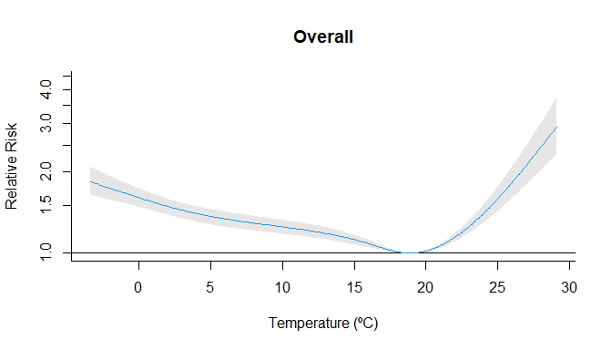

```r
plot(
  cpred,
  "overall",
  xlab = "Temperature (ºC)",
  ylab = "Relative Risk",
  col = 4,
  main = "Overall",
  log = "y"
)
```

Alternatively, we can display the posterior sampling variability by plotting the curves from all posterior samples instead of the credible interval:

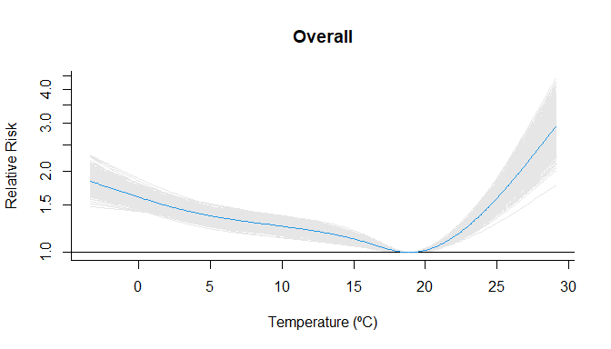

```r
plot(
  cpred,
  "overall",
  xlab = "Temperature (ºC)",
  ylab = "Relative Risk",
  col = 4,
  main = "Overall",
  log = "y",
  ci = "sampling"
)
```

We can also visualize the full exposure–lag–response association using a 3-D surface:

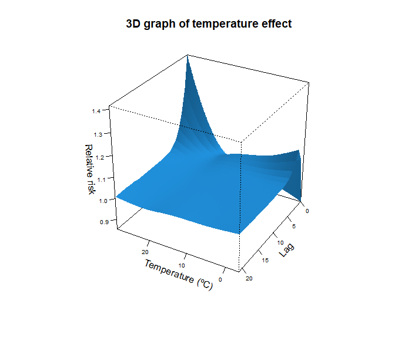

```r
plot(
  cpred,
  "3d",
  zlab = "Relative risk",
  col = 4,
  lphi = 60,
  cex.axis = 0.6,
  xlab = "Temperature (ºC)",
  main = "3D graph of temperature effect"
)
```

A contour plot provides a 2-D projection of the same relationship:

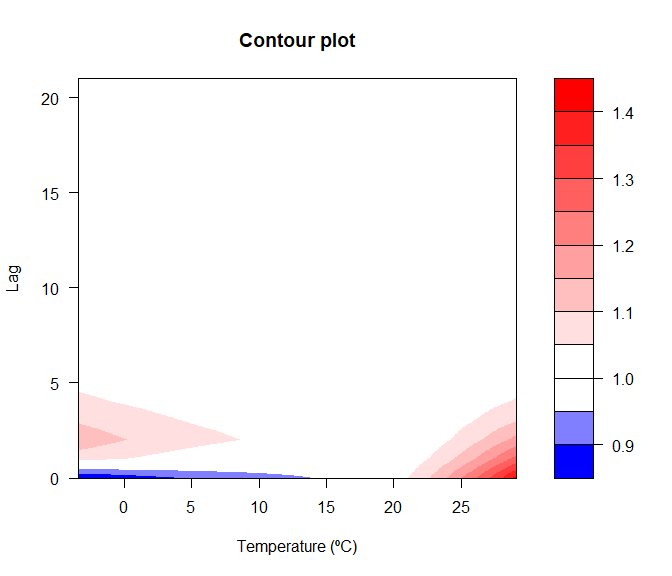

```r
plot(
  cpred,
  "contour",
  xlab = "Temperature (ºC)",
  ylab = "Lag",
  main = "Contour plot"
)
```

We can also examine the lag–response association for a high temperature (e.g., the 99th percentile):

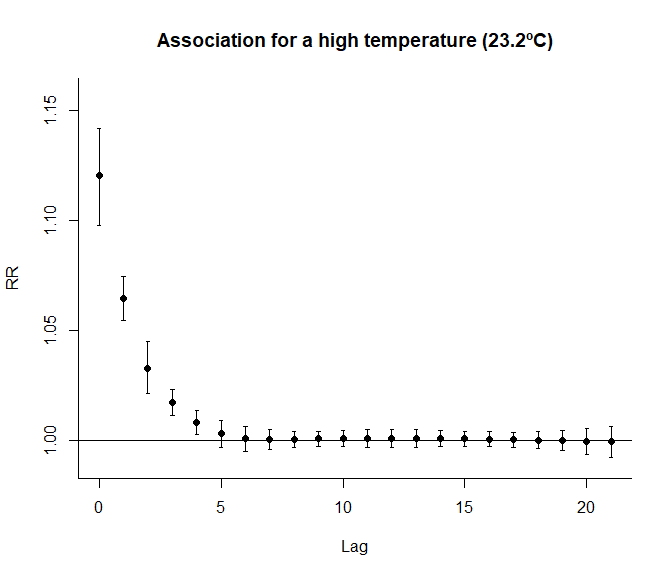

```r
htemp <- round(quantile(london$tmean, 0.99), 1)
plot(
  cpred,
  "slices",
  ci = "bars",
  type = "p",
  pch = 19,
  exp_at = htemp,
  ylab = "RR",
  main = paste0("Association for a high temperature (", htemp, "ºC)")
)
```

Or the exposure–response association at lag 0:

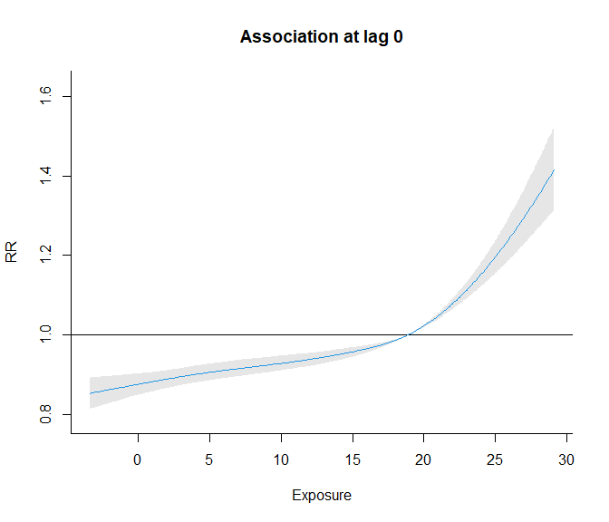

```r
plot(
  cpred,
  "slices",
  lag_at = 0,
  col = 4,
  ylab = "RR",
  main = paste0("Association at lag 0")
)
```